# Exploring the BRFSS data

## Setup

### Load packages

```r
library(ggplot2)
library(dplyr)
```

### Load data

```r
load("brfss2013.RData")
```

## Part 1: Data

### Reasoning for generabizality.

- The data have been collected by random sampling.
- Fifty-one projects used a disproportionate stratified sample (DSS) design for their landline samples. Guam and Puerto Rico used a simple random-sample design.
- The landline telephone sampling was divided into two stratas.(high density and low density each reflecting number of households respectively)
- Cellular telephone sampling also randomly selected by dividing blocks of 1000 and picking 10 on each block for the same area code and exchange within a state.

Because data was sampled randomly using the techiques as simple random sampling and stratified random sampling, we can say that sample can be used to generilze the population data.

### Reasoning for causality.

By the way the data was collected, we can say we can not infer causality. In order to be causal relationships people on the data set need to be randomly assigned into treatment and control group.

## Part 2: Research questions

**Research quesion 1:**

The correlation between: General health, Tobacco, Emotional Support. Assumption is people with good general health have greater support and lesser tobaco usage.

**Research quesion 2:**

I have been always interested on the realtionship with maritial status and life satisfaction. Assumption is people who maried satisfies with live more, because the love warms. Let’s confirm or reject that assumption using the data.

**Research quesion 3:**

Seatbelt, healthplan, genral health. Assumption is having belt when you drive and health care, the higher general health you will have.

## Part 3: Exploratory data analysis

**Research quesion 1:**

```r
brfss2013 %>%
select(genhlth, smokday2, emtsuprt) %>%
str()
```

```
## 'data.frame':    491775 obs. of  3 variables:
##  $ genhlth : Factor w/ 5 levels "Excellent","Very good",..: 4 3 3 2 3 2 4 3 1 3 ...
##  $ smokday2: Factor w/ 3 levels "Every day","Some days",..: 3 NA 2 NA 3 NA 3 1 NA NA ...
##  $ emtsuprt: Factor w/ 5 levels "Always","Usually",..: 1 3 2 2 NA NA NA NA NA NA ...
```

```r
good_hl <- brfss2013 %>%
group_by(genhlth, smokday2, emtsuprt) %>%
summarise(count = n()) %>%
filter(!is.na(genhlth), !is.na(smokday2), !is.na(emtsuprt), (genhlth == 'Good'))
good_hl["norm_count"] <- (good_hl$count / sum(good_hl$count) )

print(good_hl)
```

```
## # A tibble: 15 x 5
## # Groups:   genhlth, smokday2 [3]
##    genhlth smokday2   emtsuprt  count norm_count
##    <fct>   <fct>      <fct>     <int>      <dbl>
##  1 Good    Every day  Always      261    0.162
##  2 Good    Every day  Usually      81    0.0502
##  3 Good    Every day  Sometimes    89    0.0551
##  4 Good    Every day  Rarely       38    0.0235
##  5 Good    Every day  Never        29    0.0180
##  6 Good    Some days  Always       92    0.0570
##  7 Good    Some days  Usually      46    0.0285
##  8 Good    Some days  Sometimes    39    0.0241
##  9 Good    Some days  Rarely       11    0.00681
## 10 Good    Some days  Never        15    0.00929
## 11 Good    Not at all Always      519    0.321
## 12 Good    Not at all Usually     199    0.123
## 13 Good    Not at all Sometimes   116    0.0718
## 14 Good    Not at all Rarely       38    0.0235
## 15 Good    Not at all Never        42    0.0260
```

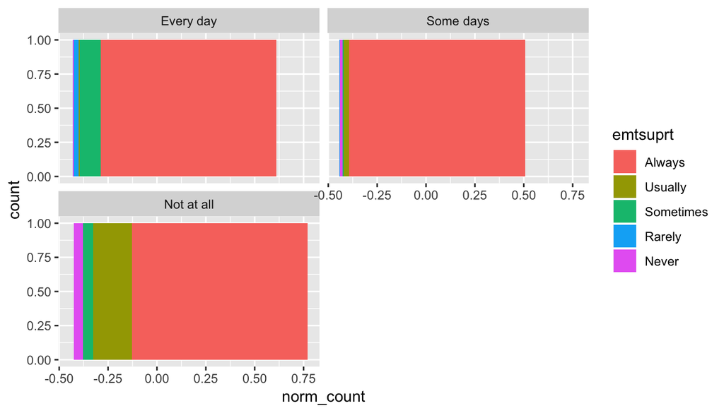

```r
ggplot(good_hl, aes(x=norm_count, fill = emtsuprt)) +
  geom_bar(position="dodge") + facet_wrap( ~ smokday2, ncol=2)
```

**Research quesion 2:**

```r
brfss2013 %>%
  select(marital, lsatisfy) %>%
  str()
```

```
## 'data.frame':    491775 obs. of  2 variables:
##  $ marital : Factor w/ 6 levels "Married","Divorced",..: 2 1 1 1 1 2 1 3 1 1 ...
##  $ lsatisfy: Factor w/ 4 levels "Very satisfied",..: 1 2 1 1 NA NA NA NA NA NA ...
```

```r
love_factor <- brfss2013 %>%
  group_by(marital, lsatisfy) %>%
  summarise(count = n()) %>%
  filter(!is.na(marital), !is.na(lsatisfy))
print(love_factor)
```

```
## # A tibble: 24 x 3
## # Groups:   marital [6]
##    marital  lsatisfy          count
##    <fct>    <fct>             <int>
##  1 Married  Very satisfied     3122
##  2 Married  Satisfied          2289
##  3 Married  Dissatisfied        189
##  4 Married  Very dissatisfied    28
##  5 Divorced Very satisfied      624
##  6 Divorced Satisfied           922
##  7 Divorced Dissatisfied        154
##  8 Divorced Very dissatisfied    49
##  9 Widowed  Very satisfied      812
## 10 Widowed  Satisfied          1097
## # … with 14 more rows
```

```r
love_factor = data.frame(love_factor)

married_total = sum(love_factor[love_factor$marital == "Married", 'count'])
never_married_total = sum(love_factor[love_factor$marital == "Never married", 'count'])

satisfied_married = love_factor[love_factor$marital == 'Married' & love_factor$lsatisfy == 'Very satisfied', 'count'] + love_factor[love_factor$marital == 'Married' & love_factor$lsatisfy == 'Satisfied', 'count']

satisfied_never_married = love_factor[love_factor$marital == 'Never married' & love_factor$lsatisfy == 'Very satisfied', 'count'] + love_factor[love_factor$marital == 'Never married' & love_factor$lsatisfy == 'Satisfied', 'count']

ratio_satisfied_married = satisfied_married / married_total

ratio_satisfied_never_married = satisfied_never_married / never_married_total

sprintf('Satisfied married: %s', ratio_satisfied_married)
```

```
## [1] "Satisfied married: 0.961442786069652"
```

```r
sprintf('Satisfied never married: %s', ratio_satisfied_never_married)
```

```
## [1] "Satisfied never married: 0.920185078079815"
```

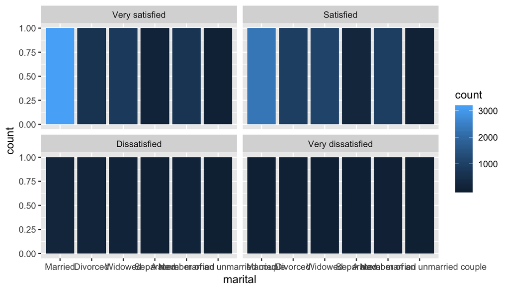

```r
ggplot(love_factor, aes(x=marital, fill = count)) +
  geom_bar(position="dodge") + facet_wrap( ~ lsatisfy, ncol=2)
```

As we can see difference between satisfied and married VS satisfied never married is really marginal only 4% roughly, this is not the big difference.

Conclusion being satisfied does not depend on your marital status(in this case considering only married vs never married)

**Research quesion 3:**

```r
brfss2013 %>%
select(seatbelt, hlthpln1, genhlth) %>%
str()
```

```
## 'data.frame':    491775 obs. of  3 variables:
##  $ seatbelt: Factor w/ 6 levels "Always","Nearly always",..: 1 1 1 1 1 1 1 1 2 1 ...
##  $ hlthpln1: Factor w/ 2 levels "Yes","No": 1 1 1 1 1 1 1 1 1 1 ...
##  $ genhlth : Factor w/ 5 levels "Excellent","Very good",..: 4 3 3 2 3 2 4 3 1 3 ...
```

```r
good_hl <- brfss2013 %>%
group_by(genhlth, hlthpln1, seatbelt) %>%
summarise(count = n()) %>%
filter(!is.na(genhlth), !is.na(hlthpln1), !is.na(seatbelt), (genhlth == 'Good'))
good_hl["norm_count"] <- (good_hl$count / sum(good_hl$count) )

print(good_hl)
```

```
## # A tibble: 12 x 5
## # Groups:   genhlth, hlthpln1 [2]
##    genhlth hlthpln1 seatbelt                      count norm_count
##    <fct>   <fct>    <fct>                         <int>      <dbl>
##  1 Good    Yes      Always                       102552   0.746
##  2 Good    Yes      Nearly always                  9908   0.0721
##  3 Good    Yes      Sometimes                      3825   0.0278
##  4 Good    Yes      Seldom                         1528   0.0111
##  5 Good    Yes      Never                          1887   0.0137
##  6 Good    Yes      Never drive or ride in a car    269   0.00196
##  7 Good    No       Always                        14037   0.102
##  8 Good    No       Nearly always                  1626   0.0118
##  9 Good    No       Sometimes                       847   0.00616
## 10 Good    No       Seldom                          359   0.00261
## 11 Good    No       Never                           518   0.00377
## 12 Good    No       Never drive or ride in a car     63   0.000458
```

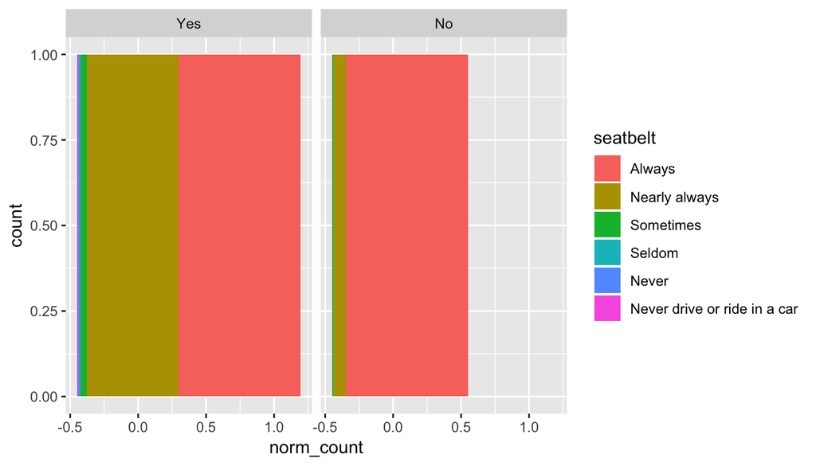

```r
ggplot(good_hl, aes(x=norm_count, fill = seatbelt)) +
  geom_bar(position="dodge") + facet_wrap( ~hlthpln1, ncol=2)
```